# Text Mining

Kaz Sakamoto

## Text Mining Libraries

```r
library(dplyr)
library(ggplot2)
library(readr)
library(tidytext)
library(stringr)
library(tidyr)
library(rvest)
library(udpipe)
library(scales)
## here we are going to find the root_file
root <- rprojroot::find_rstudio_root_file()
## we are going to set the data file path here
dataDir <- file.path(root, 'Data')
```

## Natural Language Processing

Natural language processing (NLP) is a subfield of computer science, information engineering, and artificial intelligence concerned with the interactions between computers and human (natural) languages, in particular how to program computers to process and analyze large amounts of natural language data.

Challenges in natural language processing frequently involve speech recognition, natural language understanding, and natural language generation. - from [wikipedia](https://en.wikipedia.org/wiki/Natural_language_processing)

[interactive chart not shown]

[via GIPHY](https://giphy.com/gifs/with-computers-fascination-PxSFAnuubLkSA)

In the 1980s I was convinced that computers would soon be able to simulate the basics of what (I hope) you are doing right now: processing sentences and determining their meanings.

To do this, computers would have to master three things. First, enough **syntax** to uniquely identify the sentence; second, enough **semantics** to extract its literal meaning; and third, enough **pragmatics** to infer the intent behind the utterance, and thus discerning what should be done or assumed given that it was uttered. from[Why Are We Still Waiting for Natural Language Processing?](https://www.chronicle.com/blogs/linguafranca/2013/05/09/natural-language-processing/)

## Text Mining

Text mining, also referred to as text data mining, roughly equivalent to text analytics, is the process of deriving high-quality information from text. High-quality information is typically derived through the devising of patterns and trends through means such as statistical pattern learning. Text mining usually involves the process of structuring the input text (usually parsing, along with the addition of some derived linguistic features and the removal of others, and subsequent insertion into a database), deriving patterns within the structured data, and finally evaluation and interpretation of the output. ‘High quality’ in text mining usually refers to some combination of relevance, novelty, and interest. Typical text mining tasks include text categorization, text clustering, concept/entity extraction, production of granular taxonomies, sentiment analysis, document summarization, and entity relation modeling (i.e., learning relations between named entities).

Text analysis involves information retrieval, lexical analysis to study word frequency distributions, pattern recognition, tagging/annotation, information extraction, data mining techniques including link and association analysis, visualization, and predictive analytics. The overarching goal is, essentially, to turn text into data for analysis, via application of natural language processing (NLP) and analytical methods.

A typical application is to scan a set of documents written in a natural language and either model the document set for predictive classification purposes or populate a database or search index with the information extracted. - from [Wikipedia](https://en.wikipedia.org/wiki/Text_mining)

## Tidy Text

Material from [Text Mining with R](https://www.tidytextmining.com/tidytext.html) is used to create this lab.

We talked a little bit about tidy data structures, where one observation should have its own row of data, and text data is no different. What is the unit at which we should keep in a row? well that would be the token, but what is a token? A token is a unit of text such as a word, and tokenization is the process of taking a chunk of text like a paragraph for instance and choopping it up to invidual words.

## Text Terms

- **String** text is normally stored as a charater vector.
- **Corpus** an objet that contain raw strings annotated with additional metadata
- **Document-Term Matrix** or sometimes shortened to DTM. It’s a sparse matrix describing a collection such as a corpus of documents wiht one row for each document and one column for each term. Usually word counts, term frequency or inverse document frequency will make up the values in the DTM.

## Tokens

Let’s take a bunch of Jane Jacobs quotes, which are typical bits of text that you might encounter.

```r
jacobsQuotes <- c("Cities have the capability of providing something for everybody, only because, and only when, they are created by everybody.",
"A city street equipped to handle strangers, and to make a safety asset, in itself, our of the presence of strangers, as the streets of successful city neighborhoods always do, must have three main qualities",
"First, there must be a clear demarcation between what is public space and what is private space. Public and private spaces cannot ooze into each other as they do typically in suburban settings or in projects.",
"Second, there must be eyes upon the street, eyes belonging to those we might call the natural proprietors of the street. The buildings on a street equipped to handle strangers and to insure the safety of both residents and strangers, must be oriented to the street. They cannot turn their backs or blank sides on it and leave it blind.",
"And third, the sidewalk must have users on it fairly continuously, both to add to the number of effective eyes on the street and to induce the people in buildings along the street to watch the sidewalks in sufficient numbers. Nobody enjoys sitting on a stoop or looking out a window at an empty street. Almost nobody does such a thing. Large numbers of people entertain themselves, off and on, by watching street activity."
)
```

Let’s change the quotes and create a tibble(modern data frame).

```r
text_df <- tibble(quote = 1:length(jacobsQuotes), text = jacobsQuotes)

text_df
```

```
## # A tibble: 5 x 2
##   quote text
##   <int> <chr>
## 1     1 Cities have the capability of providing something for everybody, o…
## 2     2 A city street equipped to handle strangers, and to make a safety a…
## 3     3 First, there must be a clear demarcation between what is public sp…
## 4     4 Second, there must be eyes upon the street, eyes belonging to thos…
## 5     5 And third, the sidewalk must have users on it fairly continuously,…
```

### Unnest Tokens

Now we need to take each quote and break out each word from each row. This process is called tokenization and will create a tidy data structure for analysis. The two arguments are column names, we have the output name `word` and the input `text`. You’ll see that we still have where each word came from in the `quote` column. By convenience puntuation also has been stripped and tokens are convereted to lowercase.

```r
text_df %>%
    unnest_tokens(word, text)
```

[output not shown]

Here is a workflow of a simple text mining operation with unnesting the tokens feeding into the tidyverse (dplyr) methods of data manipulation.

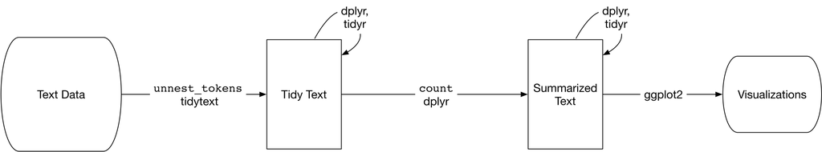

```r
text_df %>%
    unnest_tokens(word, text) %>%
    anti_join(stop_words)
```

[output not shown]

```r
text_df %>%
    unnest_tokens(word, text) %>%
    anti_join(stop_words) %>%
    count(word, sort = TRUE)
```

```
## # A tibble: 58 x 2
##    word          n
##    <chr>     <int>
##  1 street        9
##  2 strangers     4
##  3 eyes          3
##  4 buildings     2
##  5 city          2
##  6 equipped      2
##  7 handle        2
##  8 people        2
##  9 private       2
## 10 public        2
## # … with 48 more rows
```

### Citylab Example

Here is some code to scrape the top 5 stories from [citylab](https://www.citylab.com).

```r
homePage <- "https://www.citylab.com/"

topStories <- read_html(homePage) %>%
    html_nodes(css = "a.c-most-popular__link") %>%
    html_attr(name = "href")

scrapeArticle <- function(url){
    title <- read_html(url) %>%
        html_nodes("article h1") %>%
        html_text()


    text <- read_html(url) %>%
        html_nodes("article") %>%
        html_nodes(".s-article__section p") %>%
        html_text()

    tibble(title, text, section = 1:length(text))
}


textDF <- topStories %>%
    as.list() %>% purrr::map_df(~scrapeArticle(.x))

textDF %>% unnest_tokens(word, text)
```

I’ve already scraped some data so lets read in data from march 18th.

```r
textDF <- read_csv(file.path(dataDir, "cityLab3_18_19.csv"))
```

again we’re going to want to unnest the tokens and this time we’re going to remove stop_words. stop words are commonlyu used words like “the”, “a”, “an”, “in”, etc…

```r
tidy_articles <- textDF %>%
    unnest_tokens(word, text) %>%
    anti_join(stop_words)

tidy_articles %>% count(word, sort = TRUE)
```

```
## # A tibble: 1,974 x 2
##    word        n
##    <chr>   <int>
##  1 duke       46
##  2 housing    32
##  3 rail       29
##  4 light      23
##  5 homes      22
##  6 durham     21
##  7 hudson     21
##  8 kitchen    21
##  9 living     21
## 10 yards      21
## # … with 1,964 more rows
```

Let’s take a look at some graphs of the most common words in our articles

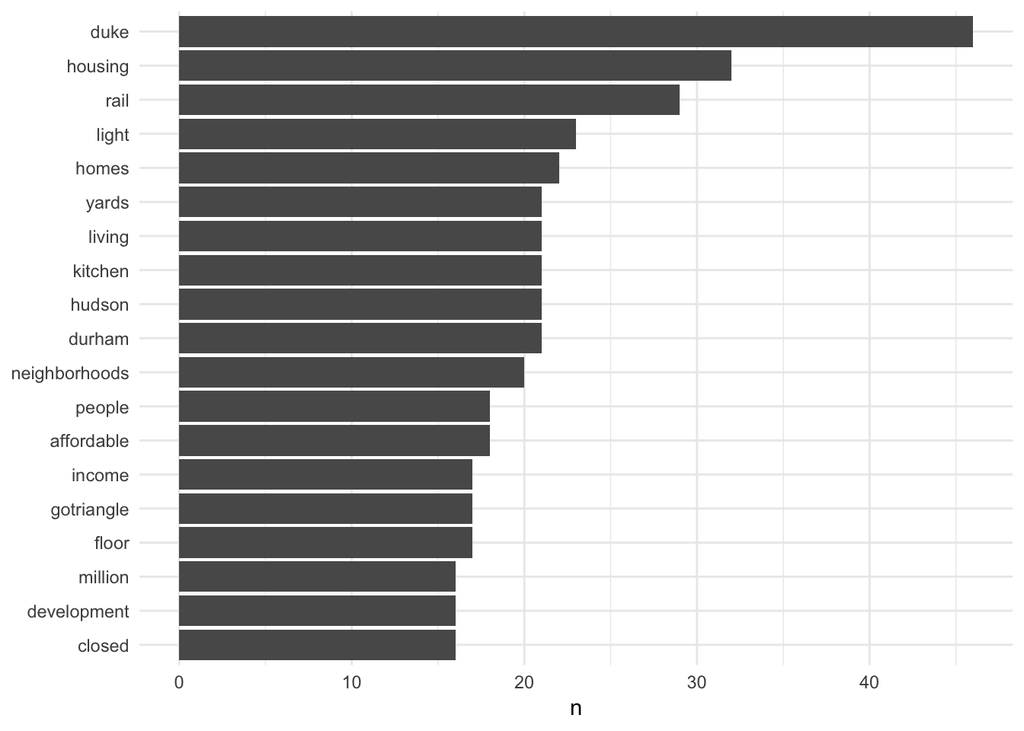

```r
library(ggplot2)

tidy_articles %>%
  count(word, sort = TRUE) %>%
  filter(n > 15) %>%
  mutate(word = reorder(word, n)) %>%
  ggplot(aes(word, n)) +
  geom_col() +
  xlab(NULL) +
  coord_flip() +
    theme_minimal()
```

### Word Frequencies

Word frequencies are a common metric used in text mining. Here we can take the our articles and calculate the porportion of the words in the articles. We could also do another analysis where we group by authors and see how different writers use words proportionately.

```r
frequency <- tidy_articles %>%
  mutate(word = str_extract(word, "[a-z']+")) %>% # take out only words
  count(title, word) %>% # count the title word pairings
  group_by(title) %>% # group by articles
  mutate(proportion = n / sum(n)) %>%  # create the proportion by article
  select(-n) %>% # remove count
  spread(title, proportion) %>% # we're going to spread by title
  gather(title, proportion, 3:6) # we're going to gather by titles except the 2nd column
```

Now we can compare word frequencies agains our first article. Words that are similar gre going lie along the dotted line. The words closest to the y axis is particular to the Hudson Yards article, while the words closest to the x axis are particular to the corresponding other articles.

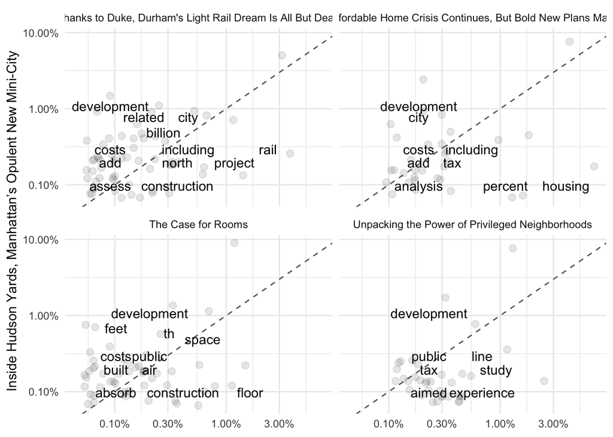

```r
# expect a warning about rows with missing values being removed
frequency %>% ggplot(aes(x = proportion,
                         y = `Inside Hudson Yards, Manhattan’s Opulent New Mini-City`)) +
    geom_abline(color = "gray40", lty = 2) +
    geom_jitter(alpha = 0.1, size = 2.5, width = 0.3, height = 0.3) +
    geom_text(aes(label = word), check_overlap = TRUE, vjust = 1.5) +
    scale_x_log10(labels = percent_format()) +
    scale_y_log10(labels = percent_format()) +
    scale_color_gradient(limits = c(0, 0.001), low = "darkslategray4", high = "gray75") +
    facet_wrap(~title, ncol = 2) +
    theme(legend.position="none") +
    theme_minimal() +
    labs(y = "Inside Hudson Yards, Manhattan’s Opulent New Mini-City", x = NULL)
```

We can also check the correlations of the articles with their words. The Durham Light Rail article is the most correlated with the Hudson Yards article with a correalation of .74 while interestingly enough has the lowest correlation with the Unpacking the Power of Priviledged Neighborhoods.

```r
cor.test(data = frequency[frequency$title == "The Affordable Home Crisis Continues, But Bold New Plans May Help",],
         ~ proportion + `Inside Hudson Yards, Manhattan’s Opulent New Mini-City`)
```

```
##
##  Pearson's product-moment correlation
##
## data:  proportion and Inside Hudson Yards, Manhattan’s Opulent New Mini-City
## t = 2.8054, df = 31, p-value = 0.008603
## alternative hypothesis: true correlation is not equal to 0
## 95 percent confidence interval:
##  0.1261537 0.6871347
## sample estimates:
##       cor
## 0.4499744
```

```r
cor.test(data = frequency[frequency$title == "Thanks to Duke, Durham's Light Rail Dream Is All But Dead",],
         ~ proportion + `Inside Hudson Yards, Manhattan’s Opulent New Mini-City`)
```

```
##
##  Pearson's product-moment correlation
##
## data:  proportion and Inside Hudson Yards, Manhattan’s Opulent New Mini-City
## t = 8.6601, df = 61, p-value = 3.245e-12
## alternative hypothesis: true correlation is not equal to 0
## 95 percent confidence interval:
##  0.6064144 0.8364668
## sample estimates:
##       cor
## 0.7426044
```

```r
cor.test(data = frequency[frequency$title == "The Case for Rooms",],
         ~ proportion + `Inside Hudson Yards, Manhattan’s Opulent New Mini-City`)
```

```
##
##  Pearson's product-moment correlation
##
## data:  proportion and Inside Hudson Yards, Manhattan’s Opulent New Mini-City
## t = 2.4028, df = 51, p-value = 0.01995
## alternative hypothesis: true correlation is not equal to 0
## 95 percent confidence interval:
##  0.05317714 0.54242762
## sample estimates:
##       cor
## 0.3188874
```

```r
cor.test(data = frequency[frequency$title == "Unpacking the Power of Privileged Neighborhoods",],
         ~ proportion + `Inside Hudson Yards, Manhattan’s Opulent New Mini-City`)
```

```
##
##  Pearson's product-moment correlation
##
## data:  proportion and Inside Hudson Yards, Manhattan’s Opulent New Mini-City
## t = 1.0592, df = 33, p-value = 0.2972
## alternative hypothesis: true correlation is not equal to 0
## 95 percent confidence interval:
##  -0.1616877  0.4852532
## sample estimates:
##       cor
## 0.1813292
```

## Part of Speech

So far we haven’t really been taking into account what kind of words we have been dealing with. Let’s use the `udpipe` [library](https://bnosac.github.io/udpipe/en/index.html). We’ll use this new package to work with parts of speech. These are already pretrained models and will help up categorize parts of speech, they also come in a myriad of langauges.

```r
# run this next line once
#model <-udpipe_download_model(language = "english-ewt")
udmodel_english <- udpipe_load_model(file = file.path(dataDir,"english-ewt-ud-2.3-181115.udpipe"))
psDF <- udpipe::udpipe_annotate(udmodel_english, textDF$text) %>% data.frame()
```

Let’s take a look at what the `psDF` data frame looks like. You’ll see that we have the `token` information, as well as `upos` which is the parts of speech. So adjectives, nouns, verbs, etc…

```r
glimpse(psDF)
```

```
## Observations: 9,010
## Variables: 14
## $ doc_id        <chr> "doc1", "doc1", "doc1", "doc1", "doc1", "doc1", "d…
## $ paragraph_id  <int> 1, 1, 1, 1, 1, 1, 1, 1, 1, 1, 1, 1, 1, 1, 1, 1, 1,…
## $ sentence_id   <int> 1, 1, 1, 1, 1, 1, 1, 1, 1, 1, 1, 1, 1, 1, 1, 1, 1,…
## $ sentence      <chr> "Conventional wisdom says that place matters more …
## $ token_id      <chr> "1", "2", "3", "4", "5", "6", "7", "8", "9", "10",…
## $ token         <chr> "Conventional", "wisdom", "says", "that", "place",…
## $ lemma         <chr> "conventional", "wisdom", "say", "that", "place", …
## $ upos          <chr> "ADJ", "NOUN", "VERB", "SCONJ", "NOUN", "NOUN", "A…
## $ xpos          <chr> "JJ", "NN", "VBZ", "IN", "NN", "NNS", "RBR", "IN",…
## $ feats         <chr> "Degree=Pos", "Number=Sing", "Mood=Ind|Number=Sing…
## $ head_token_id <chr> "2", "3", "0", "6", "6", "3", "6", "9", "6", "11",…
## $ dep_rel       <chr> "amod", "nsubj", "root", "mark", "compound", "ccom…
## $ deps          <chr> NA, NA, NA, NA, NA, NA, NA, NA, NA, NA, NA, NA, NA…
## $ misc          <chr> NA, NA, NA, NA, NA, NA, NA, NA, NA, NA, NA, NA, NA…
```

Here we can check out counts of parts of speech in our text.

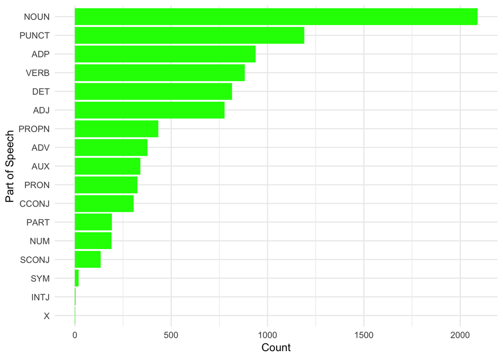

```r
txt_freq(psDF$upos) %>%
    ggplot(aes(x = reorder(key, freq), y = freq)) +
    geom_col(fill = "green") + coord_flip() +
    ylab("Count") +
    xlab("Part of Speech")+
    theme_minimal()
```

We will now subset Nouns.

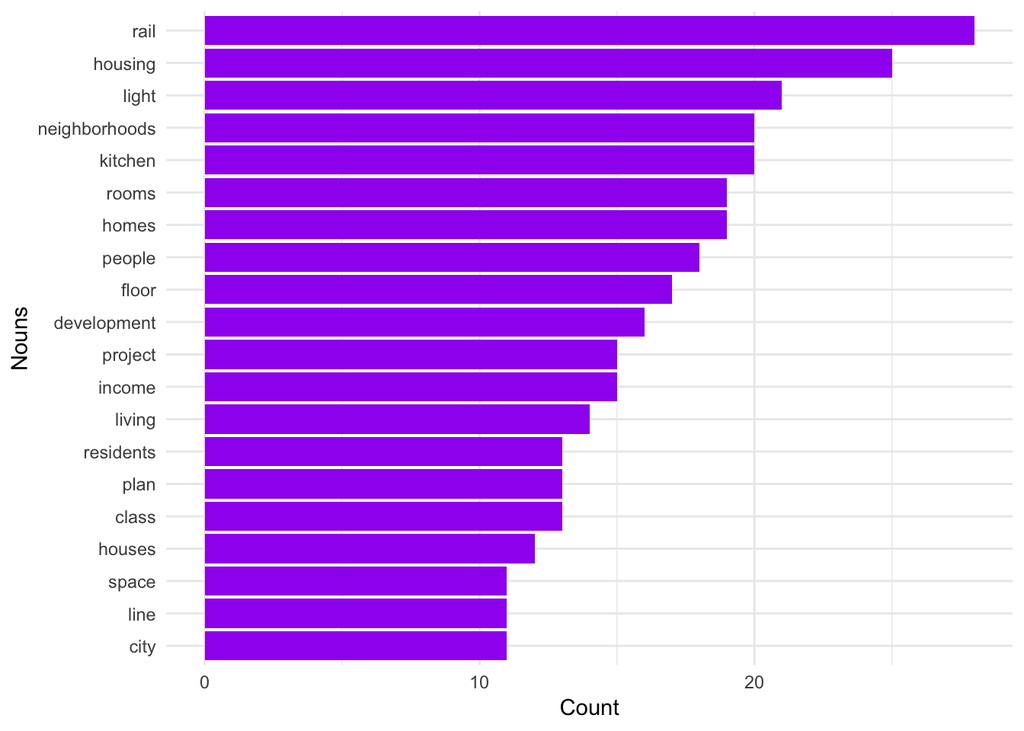

```r
nouns <- psDF %>% filter(upos %in% c("NOUN")) %>%pull(token) %>% txt_freq()
nouns %>%
    slice(1:20) %>%
    ggplot(aes(x = reorder(key, freq), y = freq))+
    geom_col(fill = "purple") + coord_flip() +
    ylab("Count") +
    xlab("Nouns")+
    theme_minimal()
```

We will now subet Verbs

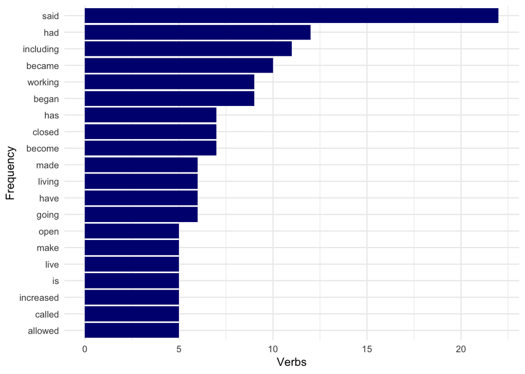

```r
verbs <- psDF %>% filter(upos %in% c("VERB")) %>%pull(token) %>% txt_freq()
verbs %>%
    slice(1:20) %>%
    ggplot(aes(x = reorder(key, freq), y = freq))+
    geom_col(fill ="navy") + coord_flip() +
    ylab("Verbs") +
    xlab("Frequency")+
    theme_minimal()
```

and finally Adjectives

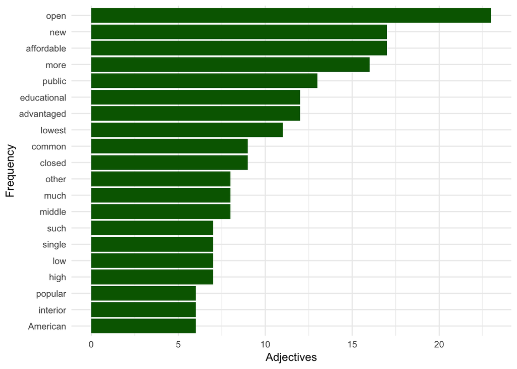

```r
adjectives <- psDF %>% filter(upos %in% c("ADJ")) %>%pull(token) %>% txt_freq()
adjectives %>%
    slice(1:20) %>%
    ggplot(aes(x = reorder(key, freq), y = freq))+
    geom_col(fill = "dark green") + coord_flip() +
    ylab("Adjectives") +
    xlab("Frequency")+
    theme_minimal()
```

### Automated Keyword Extraction

RAKE is one of the most popular (unsupervised) algorithms for extracting keywords in Information retrieval. RAKE short for Rapid Automatic Keyword Extraction algorithm, is a domain independent keyword extraction algorithm which tries to determine key phrases in a body of text by analyzing the frequency of word appearance and its co-occurrence with other words in the text. [Easy Text Analysis](https://towardsdatascience.com/easy-text-analysis-on-abc-news-headlines-b434e6e3b5b8)

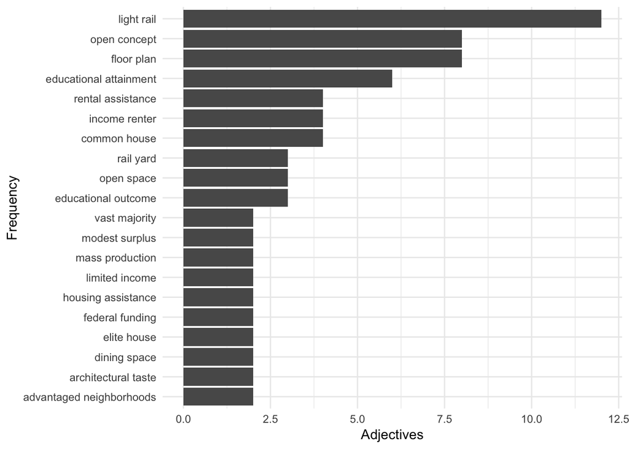

```r
stats <- keywords_rake(x = x, term = "lemma", group = "doc_id",
                       relevant = x$upos %in% c("NOUN", "ADJ"))
stats %>%
    slice(1:20) %>%
    ggplot(aes(x = reorder(keyword, freq), y = freq))+
    geom_col() + coord_flip() +
    ylab("Adjectives") +
    xlab("Frequency")+
    theme_minimal()
```

Here will simple noun phrases to collect keywords. We’ll need to convert our `upos` column to one letter tags and use some regular expressions to match our keyword combos.

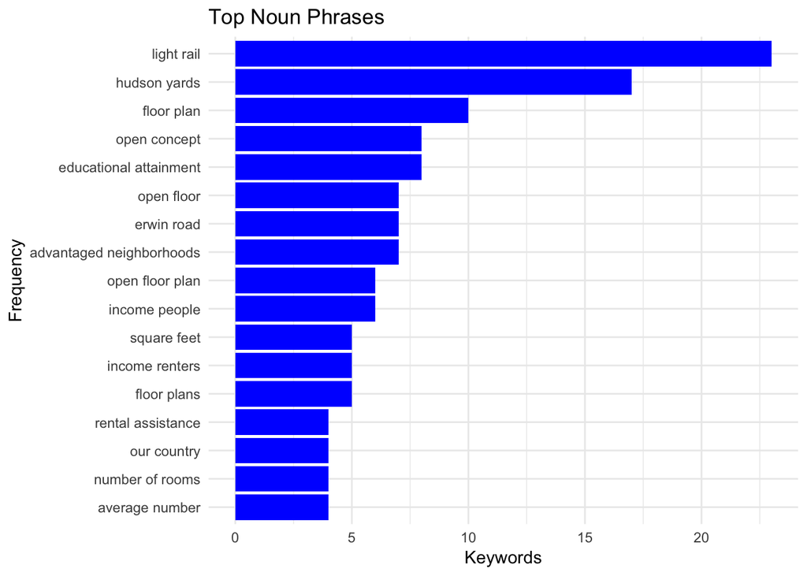

```r
x$phrase_tag <- as_phrasemachine(x$upos, type = "upos") # convert parts of speech tags to one letter tags
stats <- keywords_phrases(x = x$phrase_tag, term = tolower(x$token), #Here are the combinations of keywords we want to collect
                          pattern = "(A|N)*N(P+D*(A|N)*N)*",
                          is_regex = TRUE, detailed = FALSE) %>%
    subset(ngram > 1 & freq > 3)
stats %>%
    slice(1:20) %>%
    ggplot(aes(x = reorder(keyword, freq), y = freq))+
    geom_col(fill = "blue") + coord_flip() +
    ylab("Keywords") +
    xlab("Frequency")+
    theme_minimal() +
    ggtitle("Top Noun Phrases")
```

## Sentiment Analysis

Sentiment Analysis is also referred to as opinion mining and useful for understanding the emotional nature of text. At the simplest level, positivity and negativity in the text can be gleaned. There are more subtle emotions that can also be gained such as sadness, trust, and fear.

### Sentiments

There are three main lexicons used for sentiment analysis

- `AFINN`
- `bing`
- `nrc`

These lexicons are based on single words(unigrams) and either have positive or negative scores, or emotions.

```r
get_sentiments("afinn")
```

```
## # A tibble: 2,476 x 2
##    word       score
##    <chr>      <int>
##  1 abandon       -2
##  2 abandoned     -2
##  3 abandons      -2
##  4 abducted      -2
##  5 abduction     -2
##  6 abductions    -2
##  7 abhor         -3
##  8 abhorred      -3
##  9 abhorrent     -3
## 10 abhors        -3
## # … with 2,466 more rows
```

```r
get_sentiments("bing")
```

```
## # A tibble: 6,788 x 2
##    word        sentiment
##    <chr>       <chr>
##  1 2-faced     negative
##  2 2-faces     negative
##  3 a+          positive
##  4 abnormal    negative
##  5 abolish     negative
##  6 abominable  negative
##  7 abominably  negative
##  8 abominate   negative
##  9 abomination negative
## 10 abort       negative
## # … with 6,778 more rows
```

```r
get_sentiments("nrc")
```

```
## # A tibble: 13,901 x 2
##    word        sentiment
##    <chr>       <chr>
##  1 abacus      trust
##  2 abandon     fear
##  3 abandon     negative
##  4 abandon     sadness
##  5 abandoned   anger
##  6 abandoned   fear
##  7 abandoned   negative
##  8 abandoned   sadness
##  9 abandonment anger
## 10 abandonment fear
## # … with 13,891 more rows
```

note: that these lexicons were created using crowdsourcing or select authors and validated with an assortment of text sources. Also not all English words are captured in the lexicons since there are many neutral words.

```r
tidy_articles %>%
    filter(title == "Unpacking the Power of Privileged Neighborhoods") %>%
    inner_join(get_sentiments("nrc")) %>%
    count(sentiment, sort = TRUE)
```

```
## # A tibble: 10 x 2
##    sentiment        n
##    <chr>        <int>
##  1 positive        63
##  2 trust           39
##  3 negative        28
##  4 anticipation    26
##  5 sadness         16
##  6 joy             14
##  7 fear            11
##  8 anger            7
##  9 disgust          3
## 10 surprise         2
```

```r
articleSentiments <- tidy_articles %>%
    inner_join(get_sentiments("bing")) %>%
    count(title, index = section, sentiment) %>%
    spread(sentiment, n, fill = 0) %>%
    mutate(sentiment = positive-negative)
```

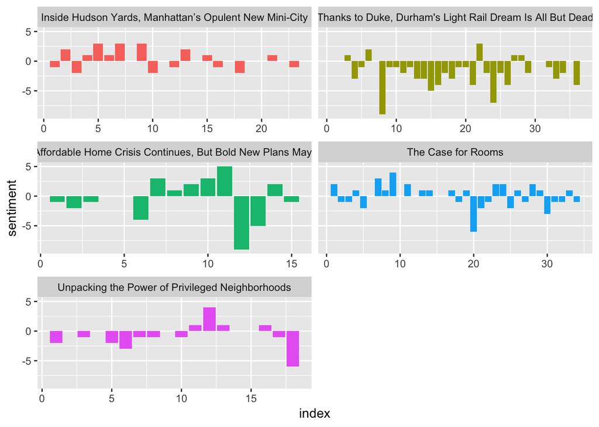

```r
articleSentiments %>% ggplot(aes(index, sentiment, fill = title)) +
    geom_col(show.legend = FALSE) +
    facet_wrap(~title, ncol = 2, scales = "free_x")
```

```r
bing_word_counts <- tidy_articles %>%
  inner_join(get_sentiments("bing")) %>%
  count(word, sentiment, sort = TRUE) %>%
  ungroup()

bing_word_counts
```

```
## # A tibble: 255 x 3
##    word          sentiment     n
##    <chr>         <chr>     <int>
##  1 rail          negative     29
##  2 affordable    positive     18
##  3 disadvantaged negative      7
##  4 issues        negative      7
##  5 concerns      negative      6
##  6 emergency     negative      6
##  7 popular       positive      6
##  8 poverty       negative      6
##  9 cooperative   positive      4
## 10 crisis        negative      4
## # … with 245 more rows
```

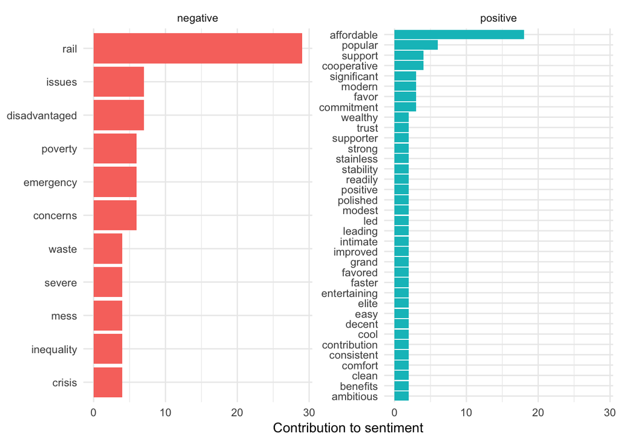

```r
bing_word_counts %>%
    group_by(sentiment) %>%
    top_n(10) %>%
    ungroup() %>%
    mutate(word = reorder(word, n)) %>%
    ggplot(aes(word, n, fill = sentiment)) +
    geom_col(show.legend = FALSE) +
    facet_wrap(~sentiment, scales = "free_y") +
    labs(y = "Contribution to sentiment",
         x = NULL) +
    coord_flip() +
    theme_minimal()
```

### Custom stop words

```r
custom_stop_words <- bind_rows(tibble(word = c("miss"),
                                          lexicon = c("custom")),
                               stop_words)

custom_stop_words
```

```
## # A tibble: 1,150 x 2
##    word        lexicon
##    <chr>       <chr>
##  1 miss        custom
##  2 a           SMART
##  3 a's         SMART
##  4 able        SMART
##  5 about       SMART
##  6 above       SMART
##  7 according   SMART
##  8 accordingly SMART
##  9 across      SMART
## 10 actually    SMART
## # … with 1,140 more rows
```

### Beyond single words

```r
tibble(text = jacobsQuotes) %>% unnest_tokens(sentence, text, token = "sentences")
```

```
## # A tibble: 10 x 1
##    sentence
##    <chr>
##  1 cities have the capability of providing something for everybody, only b…
##  2 a city street equipped to handle strangers, and to make a safety asset,…
##  3 public and private spaces cannot ooze into each other as they do typica…
##  4 second, there must be eyes upon the street, eyes belonging to those we …
##  5 the buildings on a street equipped to handle strangers and to insure th…
##  6 they cannot turn their backs or blank sides on it and leave it blind.
##  7 and third, the sidewalk must have users on it fairly continuously, both…
##  8 nobody enjoys sitting on a stoop or looking out a window at an empty st…
##  9 almost nobody does such a thing.
## 10 large numbers of people entertain themselves, off and on, by watching s…
```

```r
textDF %>% filter(title == "Unpacking the Power of Privileged Neighborhoods") %>%
    sentimentr::get_sentences(text) %>% sentimentr::sentiment() %>% head()
```

```
##                                              title
## 1: Unpacking the Power of Privileged Neighborhoods
## 2: Unpacking the Power of Privileged Neighborhoods
## 3: Unpacking the Power of Privileged Neighborhoods
## 4: Unpacking the Power of Privileged Neighborhoods
## 5: Unpacking the Power of Privileged Neighborhoods
## 6: Unpacking the Power of Privileged Neighborhoods
##                                                                                                                                                                                          text
## 1:                              Conventional wisdom says that place matters more for people who live in distressed neighborhoods—places with low median incomes and not a lot of opportunity.
## 2:                                                                                                    That’s why policymakers have traditionally focused on one of two place-based solutions.
## 3:                                                 Community development grants and tax breaks, for example, are aimed at improving conditions by luring investment into disadvantaged areas.
## 4: Housing voucher programs, meanwhile, are supposed to help low-income families escape distressed neighborhoods and move to ones with higher median incomes and better educational outcomes.
## 5:                                                                                                                           But what if our approach to geographical inequality is lopsided?
## 6:                                                                                What if we’re overlooking the contribution of so-called advantaged neighborhoods in maintaining status quo?
##    section element_id sentence_id word_count   sentiment
## 1:       1          1           1         25 -0.20000000
## 2:       1          1           2         14  0.29398737
## 3:       1          1           3         19  0.18353259
## 4:       1          1           4         26  0.06864065
## 5:       2          2           1         10 -0.34785054
## 6:       2          2           2         16  0.27500000
```

```r
out <- textDF %>% mutate(title = as.factor(title),
                         section = as.factor(section)) %>%
     sentimentr::get_sentences() %>% sentimentr::sentiment_by("title")
```

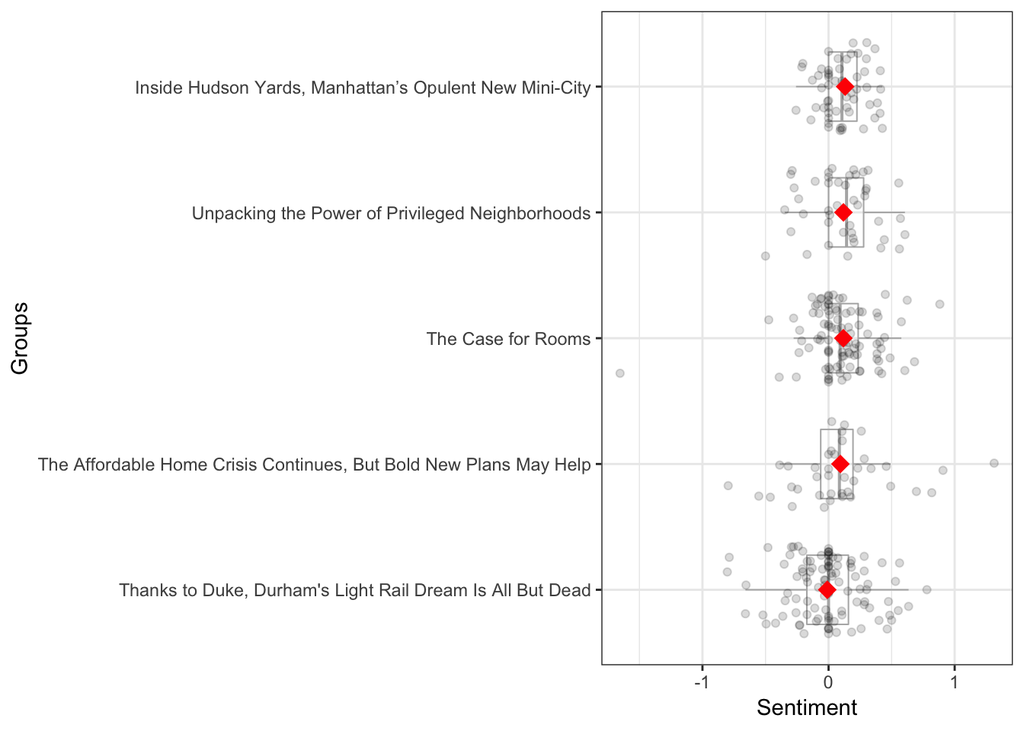

```r
plot(out)
```

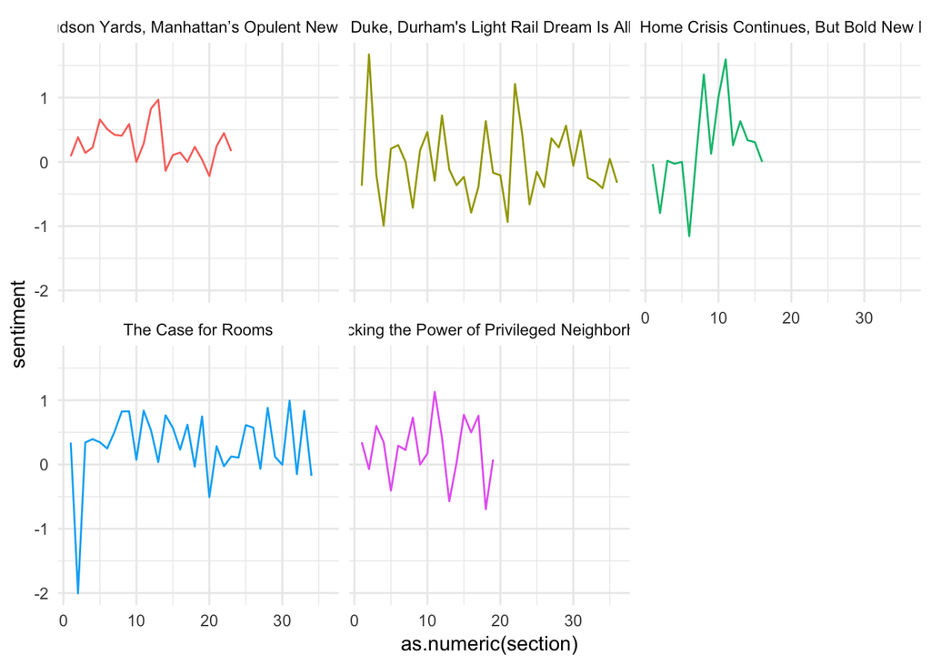

```r
out %>% sentimentr::uncombine() %>% group_by(title,section) %>%
    summarise(sentiment = sum(sentiment)) %>% ungroup() %>%
ggplot(aes(x = as.numeric(section), y = sentiment, color = as.character(title))) + geom_line(show.legend = FALSE) +
    facet_wrap(~title) + theme_minimal()
```

```r
 textDF %>% mutate(title = as.factor(title),
                         section = as.factor(section)) %>%
     sentimentr::get_sentences() %>% sentimentr::sentiment_by("title") %>%
    sentimentr::highlight()
```

## Word and Document Frequency

One measure of determining the importance of a word is the term-frequency(tf) which is how frequently does this word show up in the text? Another approach is the inverse document frequency(idf) which decreases the weight for commonly used words and increases the weight for words that don’t show up a lot. By combining these things, we get the tf-idf, which is the frequency of a term adjusted for how rare it is.

```r
article_words <- textDF %>%
    unnest_tokens(word, text) %>%
    count(title, word, sort = TRUE)
total_words <- article_words %>%
    group_by(title) %>%
    summarize(total = sum(n))

article_words <- left_join(article_words, total_words)
article_words
```

```
## # A tibble: 3,177 x 4
##    title                                                  word      n total
##    <chr>                                                  <chr> <int> <int>
##  1 The Case for Rooms                                     the     153  2231
##  2 Thanks to Duke, Durham's Light Rail Dream Is All But … the     131  2144
##  3 Inside Hudson Yards, Manhattan’s Opulent New Mini-City the     111  1396
##  4 The Case for Rooms                                     of       81  2231
##  5 The Case for Rooms                                     and      79  2231
##  6 The Case for Rooms                                     to       65  2231
##  7 Thanks to Duke, Durham's Light Rail Dream Is All But … and      62  2144
##  8 Thanks to Duke, Durham's Light Rail Dream Is All But … to       62  2144
##  9 Thanks to Duke, Durham's Light Rail Dream Is All But … a        61  2144
## 10 The Affordable Home Crisis Continues, But Bold New Pl… the      61  1016
## # … with 3,167 more rows
```

There are very long tails to the right for these articles (those extremely common words!). These plots exhibit similar distributions for all the articles, with many words that occur rarely and fewer words that occur frequently.

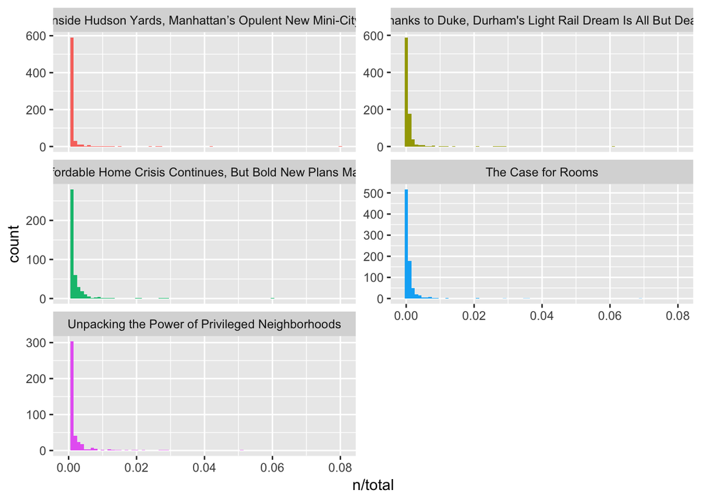

```r
ggplot(article_words, aes(n/total, fill = title)) +
  geom_histogram(show.legend = FALSE, binwidth = 0.001) +
  facet_wrap(~title, ncol = 2, scales = "free_y")
```

### Zipf’s Law

Distributions like these are typical in language. In fact, those types of long-tailed distributions are so common in any given corpus of natural language (like a book, or a lot of text from a website, or spoken words) that the relationship between the frequency that a word is used and its rank has been the subject of study; a classic version of this relationship is called Zipf’s law, after George Zipf, a 20th century American linguist.

The rank of the word times its probability(frequency) is approximately a constant

```r
freq_by_rank <- article_words %>%
  group_by(title) %>%
  mutate(rank = row_number(),
         `term frequency` = n/total)

freq_by_rank
```

```
## # A tibble: 3,177 x 6
## # Groups:   title [5]
##    title                           word      n total  rank `term frequency`
##    <chr>                           <chr> <int> <int> <int>            <dbl>
##  1 The Case for Rooms              the     153  2231     1           0.0686
##  2 Thanks to Duke, Durham's Light… the     131  2144     1           0.0611
##  3 Inside Hudson Yards, Manhattan… the     111  1396     1           0.0795
##  4 The Case for Rooms              of       81  2231     2           0.0363
##  5 The Case for Rooms              and      79  2231     3           0.0354
##  6 The Case for Rooms              to       65  2231     4           0.0291
##  7 Thanks to Duke, Durham's Light… and      62  2144     2           0.0289
##  8 Thanks to Duke, Durham's Light… to       62  2144     3           0.0289
##  9 Thanks to Duke, Durham's Light… a        61  2144     4           0.0285
## 10 The Affordable Home Crisis Con… the      61  1016     1           0.0600
## # … with 3,167 more rows
```

Here we transform our axes by changing them to logs. The articles all seem to have similar slopes, but there seems to be a section btween rank 10 and 100 where we can fit a nice linear relationship.

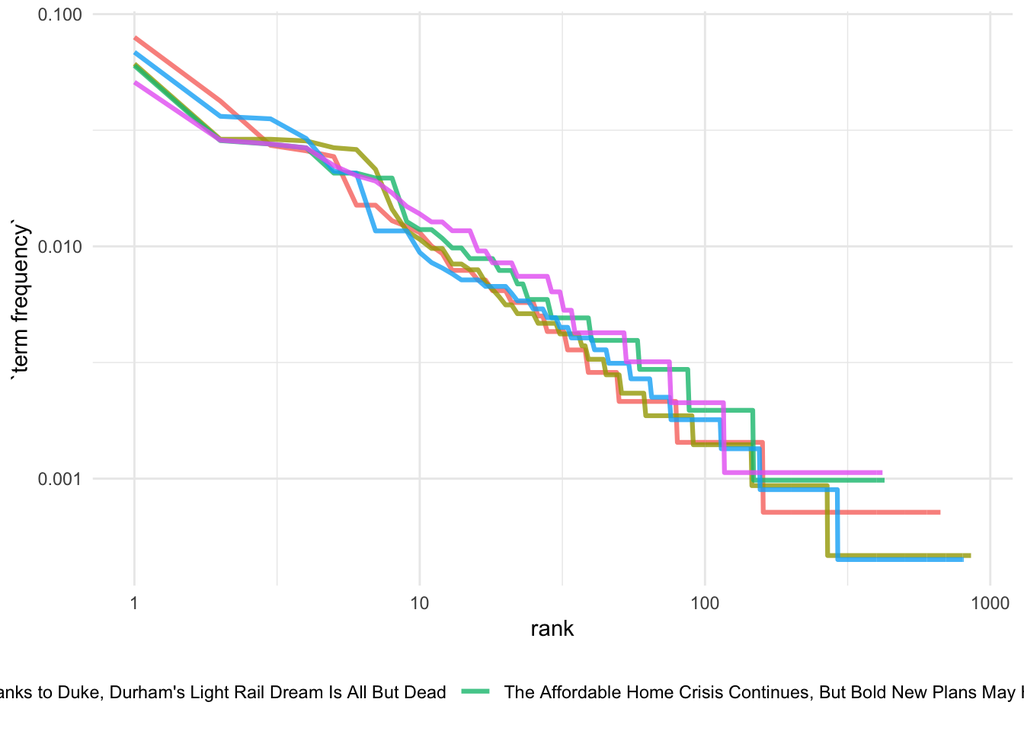

```r
freq_by_rank %>%
  ggplot(aes(rank, `term frequency`, color = title)) +
  geom_line(size = 1.1, alpha = 0.8, show.legend = TRUE) +
  scale_x_log10() +
  scale_y_log10() +
    theme_minimal() +
    theme(legend.position="bottom")
```

```r
rank_subset <- freq_by_rank %>%
  filter(rank < 100,
         rank > 10)

lm(log10(`term frequency`) ~ log10(rank), data = rank_subset)
```

```
##
## Call:
## lm(formula = log10(`term frequency`) ~ log10(rank), data = rank_subset)
##
## Coefficients:
## (Intercept)  log10(rank)
##     -1.0547      -0.8555
```

Zipf’s law is :
$$\text{frequency} \propto \frac{1}{\text{rank}}$$
our slope is -0.85 which is close to -1.

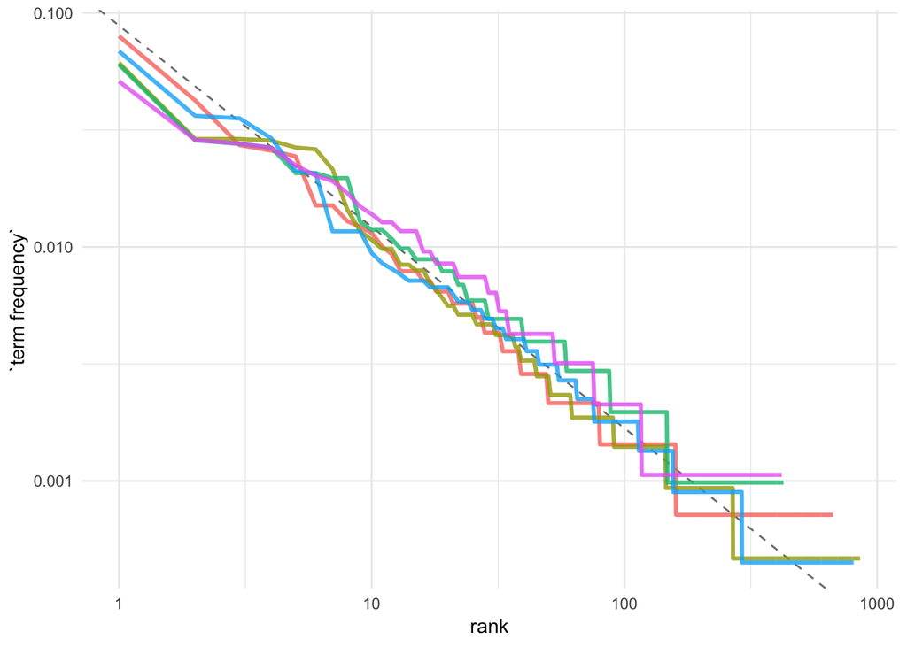

```r
freq_by_rank %>%
  ggplot(aes(rank, `term frequency`, color = title)) +
  geom_abline(intercept = -1.0546, slope = -0.86, color = "gray50", linetype = 2) +
  geom_line(size = 1.1, alpha = 0.8, show.legend = FALSE) +
  scale_x_log10() +
  scale_y_log10() +
    theme_minimal()
```

### TF IDF

The idea of tf-idf is to find the important words for the content of each document by decreasing the weight for commonly used words and increasing the weight for words that are not used very much in a collection or corpus of documents, in this case, the top five citylab articles as a whole. Calculating tf-idf attempts to find the words that are important (i.e., common) in a text, but not too common. Let’s do that now. (common locally, but rare globally)

```r
article_words <- article_words  %>%
  bind_tf_idf(word, title, n) %>%
    select(-total) %>%
    arrange(desc(tf_idf))
```

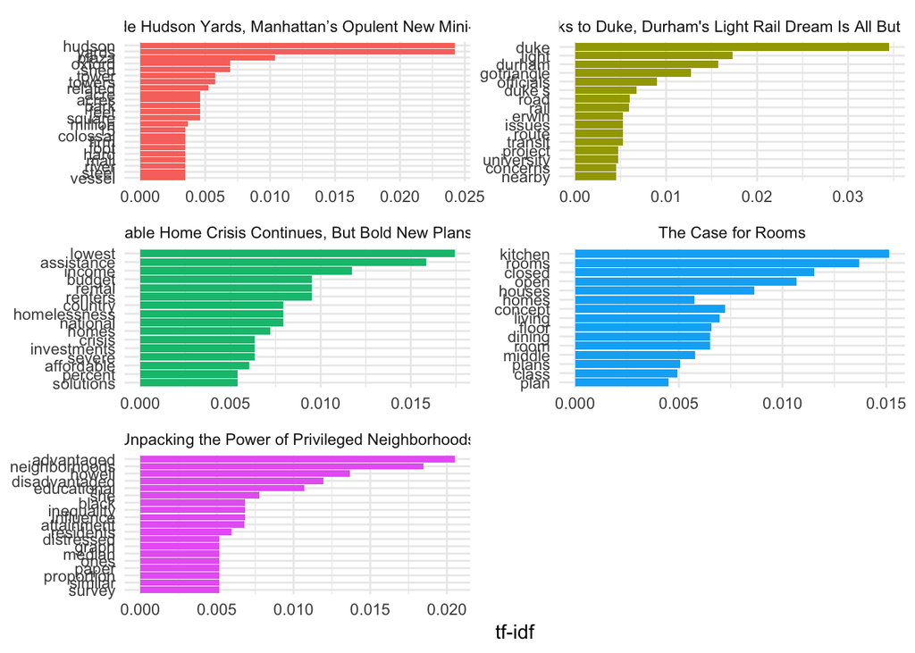

```r
article_words %>%
  arrange(desc(tf_idf)) %>%
  mutate(word = factor(word, levels = rev(unique(word)))) %>%
  group_by(title) %>%
  top_n(15) %>%
  ungroup %>%
  ggplot(aes(word, tf_idf, fill = title)) +
  geom_col(show.legend = FALSE) +
  labs(x = NULL, y = "tf-idf") +
  facet_wrap(~title, ncol = 2, scales = "free") +
  coord_flip() +
    theme_minimal()
```

## Multiple Words

single words are fine, but the relationship between words are also very important. We have alredy seen words such as Hudson Yards come up in our articles.

```r
article_bigrams <- textDF %>%
    unnest_tokens(bigram, text, token = "ngrams", n = 2)
article_bigrams
```

```
## # A tibble: 7,605 x 3
##    title                                             section bigram
##    <chr>                                               <dbl> <chr>
##  1 Inside Hudson Yards, Manhattan’s Opulent New Min…       1 great jagged
##  2 Inside Hudson Yards, Manhattan’s Opulent New Min…       1 jagged slits
##  3 Inside Hudson Yards, Manhattan’s Opulent New Min…       1 slits of
##  4 Inside Hudson Yards, Manhattan’s Opulent New Min…       1 of sky
##  5 Inside Hudson Yards, Manhattan’s Opulent New Min…       1 sky separate
##  6 Inside Hudson Yards, Manhattan’s Opulent New Min…       1 separate the
##  7 Inside Hudson Yards, Manhattan’s Opulent New Min…       1 the skyscrape…
##  8 Inside Hudson Yards, Manhattan’s Opulent New Min…       1 skyscrapers t…
##  9 Inside Hudson Yards, Manhattan’s Opulent New Min…       1 that have
## 10 Inside Hudson Yards, Manhattan’s Opulent New Min…       1 have risen
## # … with 7,595 more rows
```

```r
article_bigrams%>%
  count(bigram, sort = TRUE)
```

```
## # A tibble: 6,269 x 2
##    bigram           n
##    <chr>        <int>
##  1 of the          58
##  2 in the          35
##  3 to the          32
##  4 light rail      22
##  5 and the         20
##  6 hudson yards    17
##  7 by the          14
##  8 the light       14
##  9 for the         13
## 10 the open        13
## # … with 6,259 more rows
```

```r
bigrams_separated <- article_bigrams %>%
  separate(bigram, c("word1", "word2"), sep = " ")

bigrams_filtered <- bigrams_separated %>%
  filter(!word1 %in% stop_words$word) %>%
  filter(!word2 %in% stop_words$word)

# new bigram counts:
bigram_counts <- bigrams_filtered %>%
  count(word1, word2, sort = TRUE)

bigram_counts
```

```
## # A tibble: 1,489 x 3
##    word1       word2             n
##    <chr>       <chr>         <int>
##  1 light       rail             22
##  2 hudson      yards            17
##  3 floor       plan             10
##  4 lowest      income           10
##  5 educational attainment        8
##  6 advantaged  neighborhoods     7
##  7 erwin       road              7
##  8 middle      class             7
##  9 income      people            6
## 10 closed      floor             5
## # … with 1,479 more rows
```

```r
bigrams_united <- bigrams_filtered %>%
  unite(bigram, word1, word2, sep = " ")

bigrams_united
```

```
## # A tibble: 1,706 x 3
##    title                                           section bigram
##    <chr>                                             <dbl> <chr>
##  1 Inside Hudson Yards, Manhattan’s Opulent New M…       1 jagged slits
##  2 Inside Hudson Yards, Manhattan’s Opulent New M…       1 sky separate
##  3 Inside Hudson Yards, Manhattan’s Opulent New M…       1 reflective miss…
##  4 Inside Hudson Yards, Manhattan’s Opulent New M…       1 missile silos
##  5 Inside Hudson Yards, Manhattan’s Opulent New M…       1 western edge
##  6 Inside Hudson Yards, Manhattan’s Opulent New M…       1 hudson yards
##  7 Inside Hudson Yards, Manhattan’s Opulent New M…       1 yards mega
##  8 Inside Hudson Yards, Manhattan’s Opulent New M…       1 mega development
##  9 Inside Hudson Yards, Manhattan’s Opulent New M…       1 towers reach
## 10 Inside Hudson Yards, Manhattan’s Opulent New M…       1 1,000 feet
## # … with 1,696 more rows
```

```r
bigram_tf_idf <- bigrams_united %>%
  count(title, bigram) %>%
  bind_tf_idf(bigram, title, n) %>%
  arrange(desc(tf_idf))

bigram_tf_idf
```

```
## # A tibble: 1,499 x 6
##    title                            bigram            n     tf   idf tf_idf
##    <chr>                            <chr>         <int>  <dbl> <dbl>  <dbl>
##  1 Inside Hudson Yards, Manhattan’… hudson yards     17 0.0468 1.61  0.0754
##  2 Thanks to Duke, Durham's Light … light rail       22 0.0435 1.61  0.0700
##  3 Unpacking the Power of Privileg… advantaged n…     7 0.0393 1.61  0.0633
##  4 The Affordable Home Crisis Cont… lowest income    10 0.0361 1.61  0.0581
##  5 The Case for Rooms               floor plan       10 0.0262 1.61  0.0421
##  6 Unpacking the Power of Privileg… educational …     7 0.0393 0.916 0.0360
##  7 The Affordable Home Crisis Cont… income people     6 0.0217 1.61  0.0349
##  8 The Case for Rooms               middle class      7 0.0183 1.61  0.0295
##  9 The Affordable Home Crisis Cont… income rente…     5 0.0181 1.61  0.0291
## 10 Unpacking the Power of Privileg… black reside…     3 0.0169 1.61  0.0271
## # … with 1,489 more rows
```

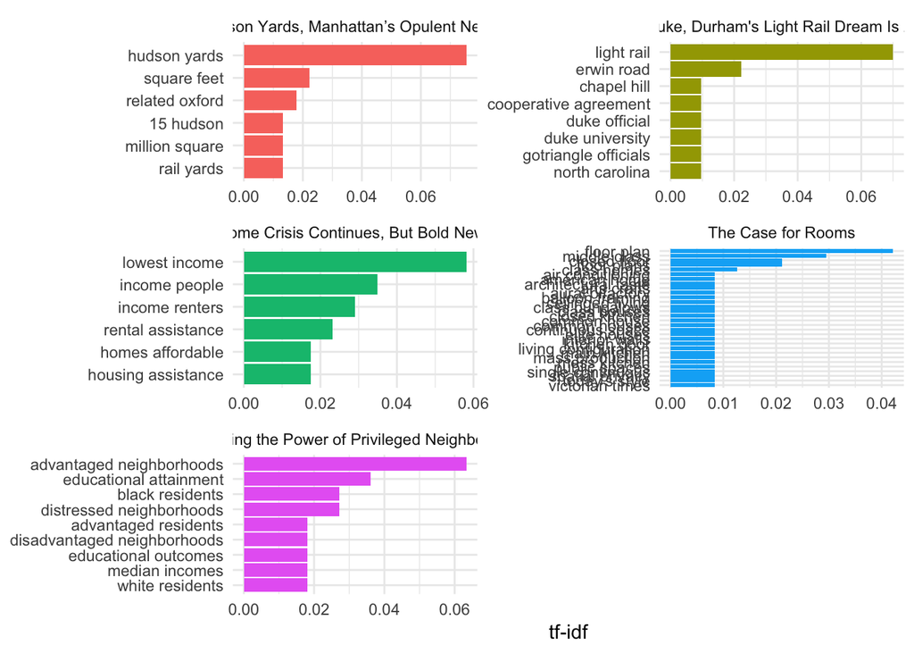

```r
bigram_tf_idf %>%
  arrange(desc(tf_idf)) %>%
  mutate(bigram = factor(bigram, levels = rev(unique(bigram)))) %>%
  group_by(title) %>%
  top_n(n = 6) %>%
  ungroup %>%
  ggplot(aes(bigram, tf_idf, fill = title)) +
  geom_col(show.legend = FALSE) +
  labs(x = NULL, y = "tf-idf") +
  facet_wrap(~title, ncol = 2, scales = "free") +
  coord_flip() +
    theme_minimal()
```

```r
not_words <- bigrams_separated %>%
  filter(word1 == "without") %>%
  inner_join(get_sentiments("afinn"), by = c(word2 = "word")) %>%
  count(word2, score, sort = TRUE) %>%
  ungroup()
not_words
```

```
## # A tibble: 1 x 3
##   word2   score     n
##   <chr>   <int> <int>
## 1 feeling     1     1
```

```r
library(igraph)
bigram_graph <- bigram_counts %>%
  filter(n > 3) %>%
  graph_from_data_frame()

bigram_graph
```

```
## IGRAPH 4f393c0 DN-- 27 16 --
## + attr: name (v/c), n (e/n)
## + edges from 4f393c0 (vertex names):
##  [1] light      ->rail          hudson     ->yards
##  [3] floor      ->plan          lowest     ->income
##  [5] educational->attainment    advantaged ->neighborhoods
##  [7] erwin      ->road          middle     ->class
##  [9] income     ->people        closed     ->floor
## [11] floor      ->plans         income     ->renters
## [13] square     ->feet          low        ->income
## [15] related    ->oxford        rental     ->assistance
```

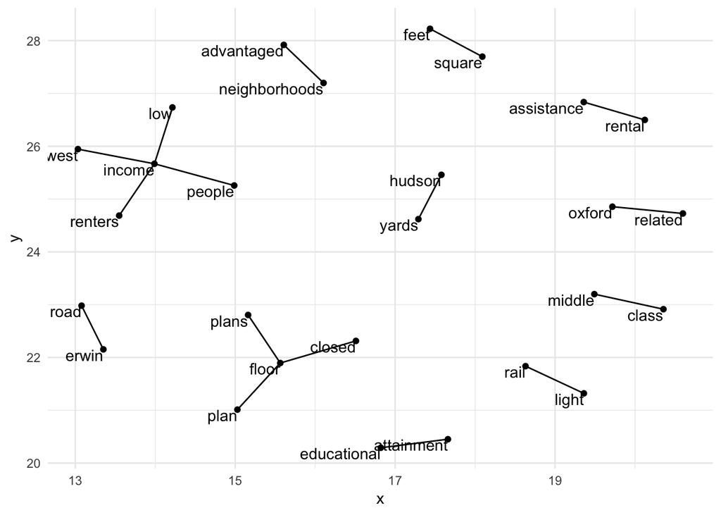

```r
library(ggraph)
ggraph(bigram_graph, layout = "fr") +
  geom_edge_link() +
  geom_node_point() +
  geom_node_text(aes(label = name), vjust = 1, hjust = 1) +
    theme_minimal()
```